# Mechanisms through which exercise reduces symptom severity and/or functional impairment in posttraumatic stress disorder (PTSD)

Simonne Wright, Virginia Chiocchia

01 June 2024

# Results

We identified 11870 records. The PRISMA flow diagram is presented in Figuare 1. A total of 11 studies with data from 771 participants were eligible for inclusion.The additional texts included secondary analyses, abstracts, trial registries, and protocol papers.

[interactive chart not shown]

**Figure 1:** PRISMA flow diagram

## Study description

10 of the studies were RCTs, and 1 was a crossover RCT (Greene & Petruzzello, 2022).The specific intervention and comparison groups for the 11 eligible studies (13 comparisons) are presented in Table 1.

| Study | Intervention | Comparison | Exercise type | Therapy | TAU | Attention control |
| --- | --- | --- | --- | --- | --- | --- |
| Bryant2023 | exercise + therapy | attention control + therapy | aerobic | exposure therapy | NA | static stretching |
| Voorendonk2023 | exercise + therapy | attention control + therapy | mixed | PE + EMDR | NA | guided (creative) tasks |
| Nordbrandt2020 | exercise + TAU | TAU | mixed | NA | combination: medical doctor, 1 to 2 sessions with social worker / psychologist | NA |
| Rosenbaum2014 | exercise + TAU | TAU | mixed | NA | combination: individual and group psychotherapy, pharmacotherapy | NA |
| Young-McCaughan2022b | exercise + therapy | therapy only | aerobic | imaginal exposure | NA | NA |
| Huseth2022 | exercise only | WLC | aerobic | NA | NA | NA |
| Young-McCaughan2022a | exercise only | TAU | aerobic | NA | self-care intervention delivering educational and instructional information | NA |
| Whitworth2019a | exercise only | attention control | anaerobic | NA | NA | videos on various educational topics (excluding exercise and mental health). |
| Whitworth2019b | exercise only | attention control | anaerobic | NA | NA | videos on various educational topics (excluding exercise and mental health). |
| Crombie2021 | exercise + extinction learning | attention control + extinction learning | aerobic | extinction learning | NA | NA |
| Greene2022a | exercise only | attention control | mixed | NA | NA | remained sedentary in the lab |
| Greene2022b | exercise only | attention control | aerobic | NA | NA | remained sedentary in the lab |
| Powers2015 | exercise + therapy | therapy alone | aerobic | prolonged exposure | NA | NA |

*Aerobic = physical performance behaviour pattern that increases heart rate and respiration while using large muscle groups repetitively and rhythmically; anaerobic = physical performance behaviour pattern that is performed in short intense bursts with limited oxygen intake; mixed = combination of aerobic and anaerobic exercise. TAU = treatment as usual; WLC = waiting list control.*

**Table 1:** Specific interventions for all the included studies

8 of the 11 studies were included in the meta-analyses (Bryant et al., 2023; Huseth, 2021; Nordbrandt et al., 2020; Rosenbaum et al., 2015; Voorendonk et al., 2023; Whitworth et al., 2019a; Whitworth et al., 2019b; Young-McCaughan et al., 2022). Meta-analysis was not feasible for 3 of the 11 studies (Crombie et al., 2021a; Greene & Petruzzello, 2022; Powers et al., 2015). Three of the studies provided follow-up PTSD outcome data which were insufficient for synthesis, which were synthesized descriptively without meta-analysis (Crombie et al., 2021a; Greene & Petruzzello, 2022; Powers et al., 2015). Three studies examined putative mediators which was not sufficient to carry out a meta-analysis (Crombie et al., 2021a; Powers et al., 2015; Whitworth et al., 2019a).

Study characteristics of the 8 studies included in the meta-analysis are are presented in Table 2. From these 8 studies, there were 9 eligible comparisons. One study presented findings from two independent comparisons, including a total of four distinct intervention groups (Young-McCaughan et al., 2022). One of the first authors published findings from two different but methodologically similar trials in the same year (Whitworth et al., 2019a; Whitworth et al., 2019b).

| Study | Year | N | Intervention | Comparison | PTSD tool | Trial registered | Exercise type | Exercise intensity | Intervention length | FU1 | FU2 | Country |
| --- | --- | --- | --- | --- | --- | --- | --- | --- | --- | --- | --- | --- |
| Bryant2023 | 2023 | 130 | exercise + therapy | attention control + therapy | CAPS-IV | yes | aerobic | high | 10 weeks | 34 weeks | NA | Australia |
| Voorendonk2023 | 2023 | 120 | exercise + therapy | attention control + therapy | PCL-5 | yes | mixed | moderate | 12 weeks | 26 weeks | NA | Netherland |
| Nordbrandt2020 | 2020 | 224 | exercise + TAU | TAU | HTQ | yes | mixed | moderate | 20 weeks | NA | NA | Denmark |
| Rosenbaum2014 | 2014 | 81 | exercise + TAU | TAU | PCL-4 | yes | mixed | high | 12 weeks | NA | NA | Australia |
| Young-McCaughan2022b | 2022 | 36 | exercise + therapy | therapy only | PCL-5 | no | aerobic | high | 8 weeks | 12 weeks | 32 weeks | USA |
| Huseth2022 | 2022 | 21 | exercise only | WLC | PCL-5 | no | aerobic | moderate | 8 weeks | NA | NA | USA |
| Young-McCaughan2022a | 2022 | 36 | exercise only | TAU | PCL-5 | no | aerobic | high | 8 weeks | 12 weeks | 32 weeks | USA |
| Whitworth2019a | 2018 | 30 | exercise only | attention control | PDS-5 | no | anerobic | high | 3 weeks | NA | NA | USA |
| Whitworth2019b | 2019 | 22 | exercise only | attention control | PDS-5 | no | anerobic | high | 3 weeks | NA | NA | USA |

*TAU = treatment as usual; WLC = waiting list control; CAPS-IV = Clinician-Administered PTSD Scale - 4th edition; PCL-4 = PTSD Checklist - version 4; PCL-5 = PTSD Checklist - version 5; PDS-5 = Posttraumatic Diagnostic Scale – version 5; HTQ = Harvard Trauma Questionnaire; Aerobic exercise = physical performance behaviour pattern that increases heart rate and respiration while using large muscle groups repetitively and rhythmically; anaerobic exercise = physical performance behaviour pattern that is performed in short intense bursts with limited oxygen intake; mixed exercise = combination of aerobic and anaerobic exercise; USA = United States of America.*

**Table 2:** Study characteristics of the 8 studies included in the meta-analysis.

Study characteristics of the 3 studies not included in the meta-analysis are are presented (Extended data). From these 3 studies, there were 4 eligible comparisons. One study reported two comparisons (Greene & Petruzzello, 2022).

[output not shown]

*Aerobic exercise = physical performance behaviour pattern that increases heart rate and respiration while using large muscle groups repetitively and rhythmically; anaerobic exercise = physical performance behaviour pattern that is performed in short intense bursts with limited oxygen intake; USA = United States of America.*

**Table 3:** Study characteristics of the 3 studies not included in the meta-analysis.

## Primary outcome

### PTSD Symptom Severity

For the studies included in the meta-analyses, the earliest study was performed in 2014, while the most recent study was performed in 2023. The median sample size across the studies was 36 participants per study. The median of the mean participant age was 37 years (ranging from 29 to 50 years).

#### Post-intervention (weeks)

8 studies provided data for PTSD symptom severity and contributed 9 effect measures to the PTSD symptom severity meta-analysis. The forest plot for PTSD symptom severity is presented in Figure 2.

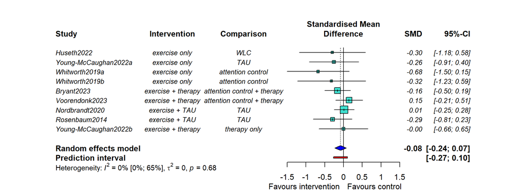

**Figure 2:** Meta-analysis of the effects of exercise on PTSD symptom severity.

The meta-analysis found no evidence of a difference in PTSD symptom severity reduction between exercise and comparison groups (SMD = -0.08, 95% CI -0.24 to 0.07). Low heterogeneity was found as suggested by the prediction interval which is only slightly wider than the confidence interval.

#### Subgroup Analyses and Meta-regressions

We explored whether heterogeneity could be potentially explained by differences in study-level characteristics using subgroup analyses and meta-regressions. The following characteristics were explored as sources of heterogeneity for the primary outcome, PTSD symptom severity:

- Exercise intensity (moderate intensity or high intensity)
- Specific exercise type (aerobic, anaerobic or mixed)
- Exercise augmented by treatment as usual (TAU)/therapy (exercise only or exercise + therapy/TAU)
- Intervention length (weeks)

##### Subgroup analysis by exercise intensity

The test for interaction found some evidence of a difference between studies with moderate intensity and those with high-intensity exercise (see Figure 3). Visual inspection of the forest plot suggests the effect is larger in the high intensity exercise subgroup.

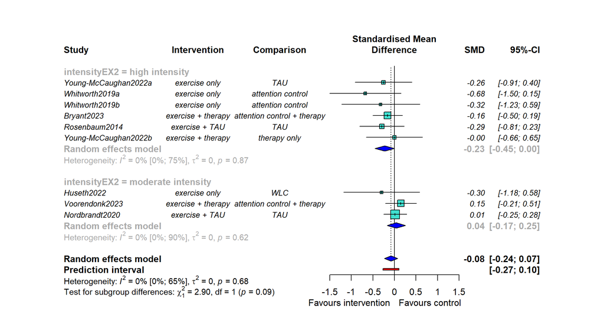

**Figure 3:** Sub-group analysis of the effects of exercise on PTSD symptom severity by exercise intensity

##### Subgroup analysis by specific exercise type

The test for interaction found no evidence of a difference in PTSD severity between aerobic, anaerobic, or mixed exercise groups (see Figure 4).

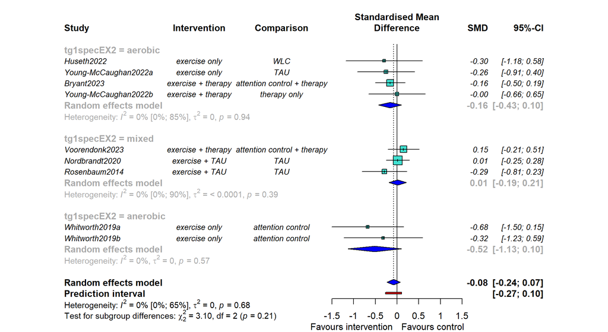

**Figure 4:** Sub-group analysis of the effects of exercise on PTSD symptom severity by specific exercise type

##### Subgroup analysis by exercise alone or tau/therapy augmented by exercise.

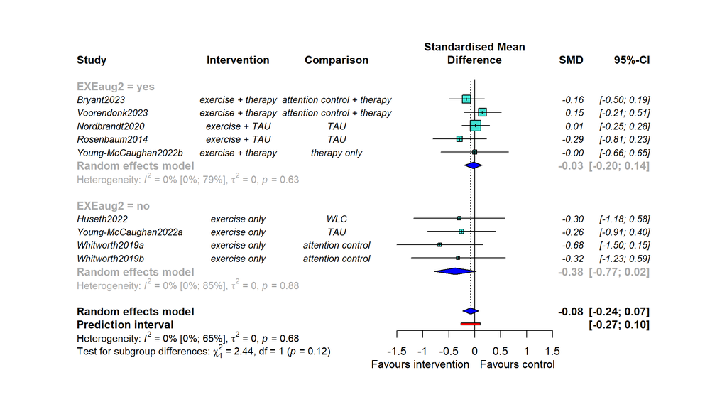

**Figure 5:** Sub-group analysis of the effects of exercise on PTSD symptom severity by exercise alone or TAU/therapy augmented by exercise

##### Meta-regression by intervention length

Overall, there is no evidence that the intervention length affected the treatment effect (see Figure 6). The meta-regression analysis yielded a coefficient of 0.02 (95% CI: -0.01, 0.05).). Intervention length ranged from 3 weeks to 20 weeks, with a mode and median of 8 weeks.

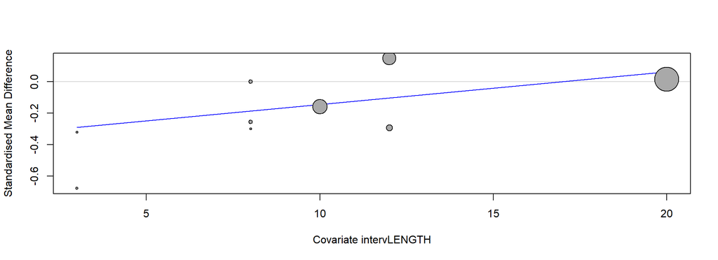

**Figure 6:** Meta-regression of the effects of exercise on PTSD symptom severity by intervention length

##### **Heterogeneity explained by covariates**

| Moderator | Category | $\beta$ | 95% CI | 𝞽<sup>2</sup> |
| --- | --- | --- | --- | --- |
| Overall effect | *-* | -0.08 | -0.24 to 0.07 | 0 |
| Exercise intensity | *-* | - | - | - |
|  | *Moderate* | 0.04 | -0.17 to 0.25 | 0 |
|  | *High* | -0.23 | -0.45 to 0 | 0 |
| Exercise type | *-* | - | - | - |
|  | *Aerobic* | -0.16 | -0.43 to 0.1 | 0 |
|  | *Anaerobic* | -0.52 | -1.13 to 0.1 | 0 |
|  | *Mixed* | 0.01 | -0.19 to 0.21 | 0 |
| Exercise augmentation | *-* | - | - | - |
|  | *Exercise alone* | -0.38 | -0.77 to 0.02 | 0 |
|  | *TAU/therapy + augmented* | -0.03 | -0.2 to 0.14 | 0 |
| Intervention length | *per unit (Week) increase* | 0.02 | -0.01 to 0.05 | 0 |

#### Sensitivity Analyses

We examine the robustness of the findings for the primary outcome by excluding studies with high risk of bias (see Figure 7). 3 studies included in the meta-analyses were rated as low or some concerns. When restricting the analysis to studies with moderate or low risk of bias, the effect of exercise on PTSD symptoms severity is SMD = -0.06 (95% CI: -0.27 , 0.14). For reference, the main effect size for the primary outcome is SMD = -0.08 (95% CI: -0.24 , 0.07), so the results do not change substantially.

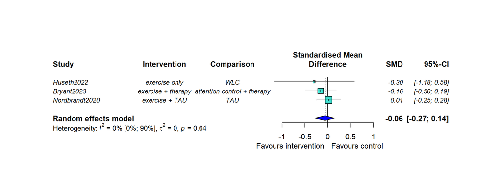

**Figure 7:** Meta-analysis of the effects of exercise on PTSD symptom severity when excluding studies with high risk of bias

#### Reporting bias

The forest plot below shows the meta-analysis results of the primary outcome ordered by the precision of the studies is presented in Figure 8. It seems that smaller studies showed larger effects favouring the intervention.

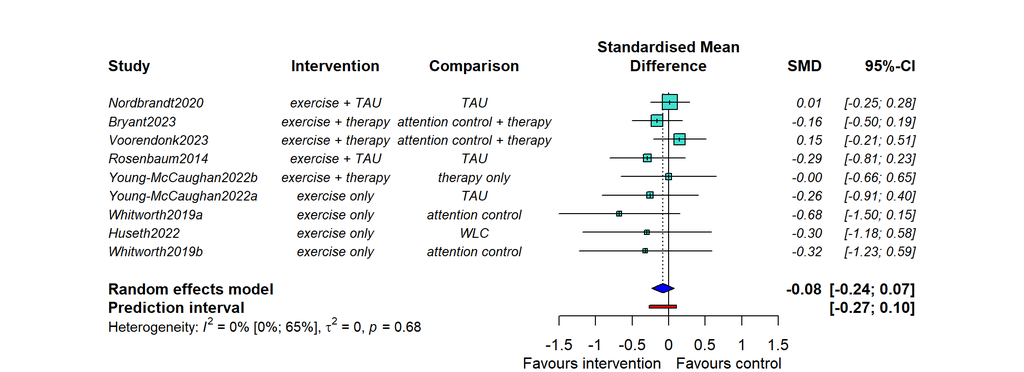

**Figure 8:** Forest plot of the meta-analysis results of the primary outcome ordered by the precision of the studies

#### Synthesis Without Meta-analysis

Meta-analysis could not be conducted for three studies addressing the primary outcome of PTSD symptom severity (Crombie et al., 2021a; Greene & Petruzzello, 2022; Powers et al., 2015). Two of the studies did not report outcome data for PTSD symptom severity post-intervention (Crombie et al., 2021a; Greene & Petruzzello, 2022). The third study did not provide sufficient data to include in the meta-analysis (Powers et al., 2015).  
Powers et al. (2015) examined the efficacy of adding moderate-intensity aerobic exercise before prolonged exposure (PE) in reducing PTSD symptoms. The participants who underwent PE plus exercise experienced a greater reduction in PTSD symptoms (d = 2.65, SE = 0.92). compared to the group that received PE only. This outcome was observed after the 12-week intervention.

#### Risk of bias for the PTSD symptom severity

The results of the risk of bias assessment per domain and study for the primary outcome, PTSD symptom severity is presented below in Figure 9 of the Extended Data. Nine studies reported PTSD outcome data post-intervention. Two studies did not report PTSD outcome data (Crombie et al., 2021a; Greene & Petruzzello, 2022). Five of the nine studies had an overall high risk of bias, three had some concerns, and only one was had low risk of bias. High risk of bias was mainly due to deviations from intended intervention (D2)(Voorendonk et al., 2023; Whitworth et al., 2019a; Whitworth et al., 2019b), missing outcome data (D3)(Rosenbaum et al., 2015; Voorendonk et al., 2023; Whitworth et al., 2019a; Whitworth et al., 2019b), and selection of reported results (D5)(Voorendonk et al., 2023; Young-McCaughan et al., 2022).

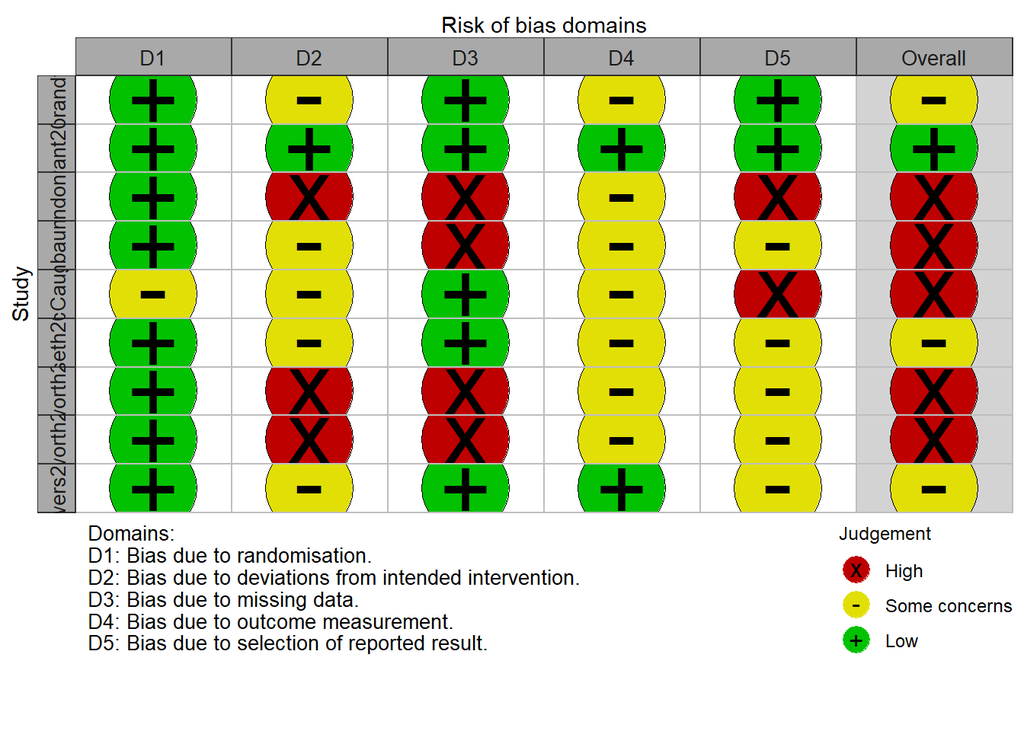

**Figure 9** Results of the risk of bias assessment per domain and overall for the PTSD severity outcome

## Secondary outcomes

### Treatment Dropout

#### Post-intervention (weeks)

8 studies provided data for treatment dropout, and contributed 9 effect measures to the treatment dropout meta-analysis. The forest plot for the risk of treatment dropout presented in Figure 10.

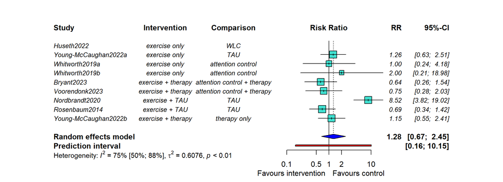

**Figure 10:** Meta-analysis of the dropout rates between the intervention and control groups

There is no evidence of a difference in treatment dropout between exercise and comparison groups (RR = 1.28, 95% CI 0.67 to 2.45) and there is large heterogeneity, as shown by the prediction interval (0.16 to 10.15).

### PTSD symptom clusters

#### Synthesis without meta-analysis

2 of the 11 studies examined the effects of exercise on PTSD symptom clusters, namely, avoidance, reexperiencing, hyperarousal, as well as negative cognitions and mood (Whitworth et al., 2019a; Whitworth et al., 2019b). One study reported significantly lower levels of avoidance symptoms (F(1, 20) = 8.50, p=.009, d=1.26, 95% CI [0.39, 2.14] and hyperarousal symptoms (F(1, 20) = 4.41, p = .049, d = 0.90, 95% CI [0.06, 1.74]) in the exercise group relative to the control group post-intervention (Whitworth et al., 2019a). While intrusion, F(1,20) = 2.48, p = .131, d = 0.67, 95% CI [−0.15, 1.49]; and mood and cognitive symptoms F(1, 20) = 0.65, p = .442, d = 0.34, 95% CI [−0.47, 1.14] did not differ significantly (Whitworth et al., 2019a). The other study found no significant between-group differences for intrusion (F(1, 17) < 0.01, p=0.98), avoidance (F(1, 17) = 0.63, p = 0.49), mood and cognitive symptoms (F(1, 17) = 0.02, p=0.91), and hyperarousal symptoms (F(1, 17) = 0.21, p = 0.67) between the exercise and comparison group (Whitworth et al., 2019b)

### Functional impairment

#### Synthesis without meta-analysis

Two of the studies examined the effects of exercise on functional impairment post-intervention indices (Nordbrandt et al., 2020; Voorendonk et al., 2023). One study reported small significant improvement over time for Quality of life evaluated (mean difference (SE) = 9.68 (2.79), p = .0005)(Topp et al., 2015), Global Assessment of Functioning for Symptom (mean difference (SE) = 4.37 (1.34), p = .0011)(Bastin et al., 2013), as well as level of functioning (mean difference (SE) =-2.54 (0.86), p = .0032)(Sheehan & Sheehan, 2008) for the exercise group (Nordbrandt et al., 2020). However, no significant difference over time was found for the Global Assessment of Functioning for Function (mean difference (SE) = 3.64 (1.31), p = .05990) (Bastin et al., 2013) in the exercise group (Nordbrandt et al., 2020). While most variables showed significant improvement in rating scores over time in both the exercise and comparison group, no significant between-group differences were found at the pre- or post-intervention assessments. The other study reported a large significant increase in quality of life (Priebe et al., 1999) in both the exercise and comparison groups, and also found no significant between group differences (Voorendonk et al., 2023).

### Loss of PTSD diagnosis

#### Synthesis without meta-analysis

Only one study reported data on loss of PTSD diagnosis post-intervention (Voorendonk et al., 2023). Loss of diagnosis was high in both the exercise and comparison groups. More specifically, 80.0% and 82.7% of the intervention and comparison groups respectively no longer met the diagnostic criteria for PTSD. The between-group difference was non-significant (p = 0.721).

## Mechanistic insights

Three studies examined putative mediators, but the available data was insufficient to carry out a meta-analysis (Crombie et al., 2021a; Powers et al., 2015; Whitworth et al., 2019a).

#### Risk of bias for the mediation studies

[figure not shown]

# SUMMARY OF THE EVIDENCE

The primary outcome was efficacy in reducing overall PTSD symptom severity in patients with PTSD. The summary of the evidence on PTSD symptom severity outcome for PTSD is reported below.

| Source of evidence | Summary of the association | Bias due to study limitations | Bias due to reporting bias | Bias due to indirectedness | Bias due to other reasons |
| --- | --- | --- | --- | --- | --- |
| Exercise intervention vs comparison group | n = 9 , k = 700 , SMD = -0.08, 95%CI: -0.24, 0.07 | Overall, five studies were rated as high, three studies as some concerns, and one was rated as low risk of bias. High risk of bias due to to deviations from intended intervention, missing outcome data… | It appears that the smaller studies showed larger effects favouring the intervention. | NA | Lack of blinding of participants and outcomes assessors. |